# lab1

I.A little statistics

```python
%matplotlib inline
import numpy as np
import matplotlib
import matplotlib.pyplot as plt
import scipy
from scipy import stats
from scipy.stats import binom

#this sets the size of the plot to something useful
plt.rcParams["figure.figsize"] = (15,10)
```

```python
d = stats.norm.rvs(loc = 5., scale = 0.01, size = 100000)
```

1.A

```python
X = np.array([1.,2.,5.])
prob = .5 * scipy.special.erfc(X/(2**.5))
prob
```

```
array([1.58655254e-01, 2.27501319e-02, 2.86651572e-07])
```

1.B

```python
stats.norm.cdf(1.3)
```

```
0.9031995154143897
```

```python
stats.norm.cdf(2)
```

```
0.9772498680518208
```

```python
stats.norm.cdf(2.5)
```

```
0.9937903346742238
```

1.C

```python
stats.norm.ppf(0.9031995154143897)
```

```
1.3000000000000003
```

```python
stats.norm.ppf(0.9772498680518208)
```

```
2.0000000000000004
```

```python
stats.norm.ppf(0.9937903346742238)
```

```
2.4999999999999987
```

2.A

Rayleigh

2.B

```python
d = stats.rayleigh.rvs(loc = 5., scale = 0.01, size = 100000)
```

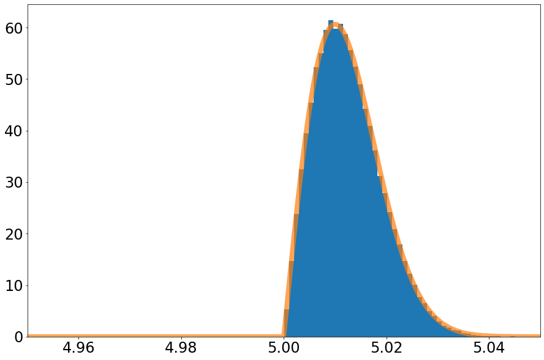

```python
fig, ax = plt.subplots(1, 1)
ax.hist(d,50, density=True)
plt.tick_params(labelsize = 24)
plt.xlim([4.95,5.05])
x = np.linspace(4.95,5.05,1000)
ax.plot(x,stats.rayleigh.pdf(x,loc = 5., scale = 0.01),linewidth = 8,alpha = 0.7)
plt.show()
```

3.A

5.02

3.B

What's the probability of 5.02 is a signal?

3.C

3.D

```python
stats.rayleigh.cdf(5.020, loc = 5., scale = 0.01)
```

```
0.8646647167633758
```

3.E

```python
stats.rayleigh.ppf(0.8646647167633758, loc = 5., scale = 0.01)
```

```
5.02
```

4.Pick 4.98 and 5.1

```python
stats.rayleigh.cdf(4.98, loc = 5., scale = 0.01)
```

```
0.0
```

```python
stats.rayleigh.ppf(0, loc = 5., scale = 0.01)
```

```
5.0
```

```python
stats.rayleigh.cdf(5.1, loc = 5., scale = 0.01)
```

```
1.0
```

```python
stats.rayleigh.ppf(1, loc = 5., scale = 0.01)
```

```
inf
```

II.Non-continuous distributions

A.Binomial

B.Plot

[figure not shown]

```python
n = 10
p = 0.75
r_values = list(range(n + 1))
dist = [binom.pmf(r, n, p) for r in r_values ]
plt.bar(r_values, dist)
plt.show()
```

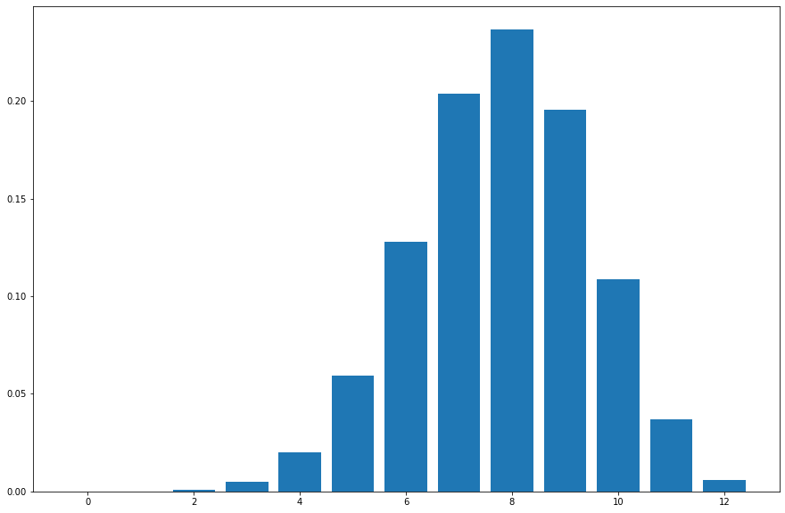

```python
n = 12
p = 0.65
r_values = list(range(n + 1))
dist = [binom.pmf(r, n, p) for r in r_values ]
plt.bar(r_values, dist)
plt.show()
```

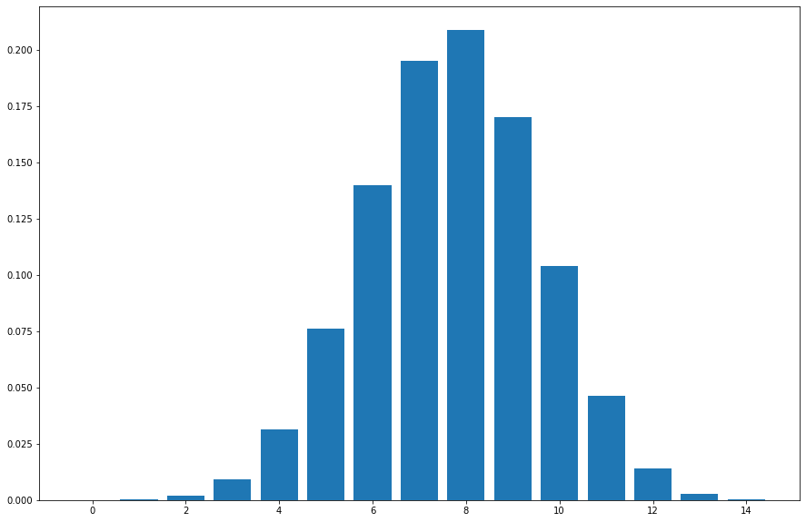

```python
n = 14
p = 0.55
r_values = list(range(n + 1))
dist = [binom.pmf(r, n, p) for r in r_values ]
plt.bar(r_values, dist)
plt.show()
```

When p more closer to 0.5, the distribution more symmetric. The p point will be the highest. The data will be more detailed when n is greater.

C.There are 12 student, the probability that they failed class is 0.3, what's the probability that they all passed the class.

```python
stats.binom.cdf(0,12,0.3)
```

```
0.01384128720099999
```

```python
stats.binom.ppf(0.01384128720099999,12,0.3)
```

```
0.0
```

D.Because the distributions are discrete, so there's no a continuous probability curve. Mean or median won't be the best choice, we can choose a relative high probability number.

E.Mean might not be a integer. The data are discrete, so the mean is 9.2 make sense. 9 gamma-rays might be more than 10 gamma-rays, that cause the mean is 9.2. what changes continuously and what doesn't, that depends on what kind of data we collected. For example, number of students of different high school, it's a discrete data. Age or height of a group of people, it's a continuously data.